# HW3

Kwan Ho Lee

4/27/2021

## Problem 1

### 1a)

Let’s take a derivative of given log-likelihood function
$$\frac{d\;l(\theta)}{d\;\theta} = \frac{x_1}{2+\theta} -
\frac{x_2+x_3}{1-\theta} + \frac{x_4}{\theta} = 0
\\
\iff \frac{x_1}{2+\theta} = \frac{(x_2 + x_3)\theta -
(1-\theta)x_4}{(1-\theta)\theta}
\\
\iff \theta x_1 - \theta^2x_1 = (x_2+x_3)(2\theta + \theta^2) - (2 - \theta -
\theta^2)x_4
\\
\iff (x_1 + x_2 + x_3 + x_4)\theta^2 + (x_4 + 2x_2 + 2x_3 - x_1)\theta - 2x_4 =
0$$

Substituting the oberved data, we obtain $199\theta^2 - 10\theta - 66= 0$. By using the quadratic formula, we solve and observe $\hat{\theta} = 0.60157$.

### 1b)

$$Q(\theta,\theta^{(k)}) = E_{\theta^{(k)}} [l_c(\theta)|\mathbf{X}]
= E_{\theta^{(k)}} [(x_{12} + x_4) \log \theta + (x_2 +
x_3)\log(1-\theta)|\mathbf{X}]
\\
= (E_{\theta^{(k)}} [x_{12}|\mathbf{X}] + x_4) \log \theta + (x_2 +
x_3)\log(1-\theta)
= \left[ x_1 \left( \frac{\theta^{(k)}/4}{1/2 + \theta^{(k)}/4} \right) + x_4
\right] \log \theta + (x_2 + x_3)\log(1-\theta)$$

Assume $\left( \frac{\theta^{(k)}/4}{1/2 + \theta^{(k)}/4} \right)=b$ and differentiate and set equal to $0$, then we obtain

$$\frac{x_1b + x_4}{\theta} - \frac{(x_2 + x_3)}{1-\theta} = 0
\\
\iff \theta(x_2 + x_3) = (x_1b + x_4)(1-\theta)
\\
\iff \theta(x_2 + x_3 + x_1b + x_4) = x_1b + x_4
\\
\iff \theta^{(k+1)} = \frac{x_1b + x_4}{x_2 + x_3 + x_1b + x_4}$$

```
## [1] 0.6015713 0.6015713 0.6015713 0.6015713 0.6015713
```

### 1c)

```
## [1] 1.279219e-06
```

By comparing part a and b, we could see the difference is 1.279219e-06, which is pretty close to zero.

## Problem 3

### 3a)

Let’s develop the EM algorithm, we start with the likelihood function,

$$L_c(\alpha) = \prod_{i=1}^n \frac{2y_i}{\alpha^2} \exp
\left(-\frac{y_i^2}{\alpha^2} \right)
= \frac{2^n \prod_{i=1}^n y_i}{\alpha^{2n}} \exp \left( -\frac{1}{\alpha^2}
\sum_{i=1}^n y_i^2 \right)$$

Then the log-likelihood function is,
$$l_c(\alpha) = -2n \log \alpha - \frac{1}{\alpha^2} \sum_{i=1}^n y_i^2 + c$$

Define an expression for $Q(\alpha,\alpha_{(k)})$,
$$Q(\alpha,\alpha_{(k)}) = \mathbb{E}_{\alpha_{(k)}} [l_c(\alpha)|\mathbf{X}]
= -2n \log \alpha - \frac{1}{\alpha^2} \sum_{i=1}^n \mathbb{E}_{\alpha_{(k)}}
[y_i^2|\mathbf{X}]$$

$$\mathbb{E}_{\alpha_{(k)}} [y_i^2|\mathbf{X}] = \mathbb{E}_{\alpha_{(k)}}
[y_i^2|y_i=y_i] = y_i^2$$

For the censored data, we need to integrate as below
$$\mathbb{E}_{\alpha_{(k)}} [y_i^2|\mathbf{X}] = \mathbb{E}_{\alpha_{(k)}}
[y_i^2|y_i > c_i]
= \int_{c_i}^{\infty} \frac{2y_i^3}{\alpha_{(k)}^2} \exp \left(
-\frac{y_i^2}{\alpha_{(k)}^2} \right) d{y_i}
= (\alpha_{(k)}^2 + c_i^2) \exp \left( -\frac{c_i^2}{\alpha^2_{(k)}} \right)$$

Assume $K = \sum_{i=1}^n \mathbb{E}_{\alpha^{(k)}} [y_i^2|\mathbf{X}]$, then we have
$$K = \sum_{i=1}^r y_i^2 + \sum_{i=r+1}^n (\alpha^2_{(k)} + c_i^2) \exp \left(
-\frac{c_i^2}{\alpha^2_{(k)}} \right)$$

For the M-step, we maximize $Q(\alpha,\alpha_{(k)})$ as below
$$Q(\alpha,\alpha_{(k)}) = -2n \log \alpha - \frac{1}{\alpha^2} M
\frac{dQ}{d\alpha} = -\frac{2n}{\alpha} + \frac{2}{\alpha^3} M = 0$$

### 3b)

Solving for $\alpha$, we obtain $\alpha_{(k+1)} = \sqrt{K/n}$, where $K$ is given above.

```
##  [1] 2.567647 2.567647 2.567647 2.567647 2.567647 2.567647 2.567647 2.567647
##  [9] 2.567647 2.567647
```

We run the algorithm for $100$ iterations with $10$ distinct starting points $\alpha^{(0)} = 1, 2, ..., 10$, we obtain $\hat{\alpha} = 2.567647$ for each distinct starting point.

## Problem 4

$f(x)\propto e^{-x} \implies f(x) = \frac{1}{N}e^{-x}$ where $N = (\int_{0}^{2}e^{-x}dx)^{-1} = \frac{1}{1-e^{-2}}$.
$$F(x) = \frac{1}{N}\int_{0}^{x}e^{-y}dy =
\frac{1-e^{-x}}{1-e^{-2}}1_{x\in[0,2]}$$

By inverting $F(x)$, we could observe below
$$F(x) = u \implies \frac{1-e^{-x}}{1-e^{-2}} = u \implies
(1-e^{-2})u = 1-e^{-x} \implies x = -\log(1-u(1-e^{-2}))$$

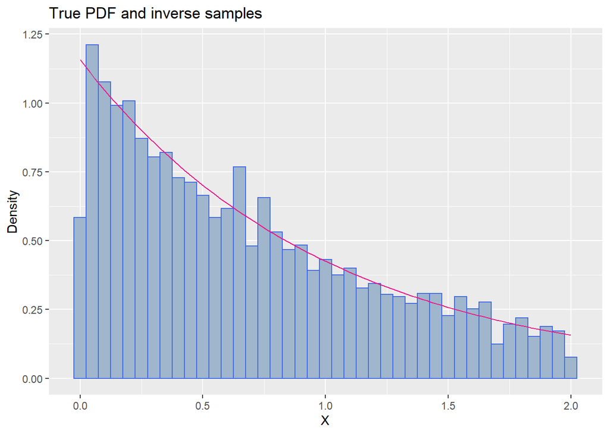

## Problem 5

We need to find the normalization constant $N$ as follows, $f(x) = \frac{1}{N}\frac{e^{-x}}{1+x^2}$ so $\int_0^{\infty} f(x)dx = 1 \implies N = \int_{0}^{\infty} q(x)dx \approx 0.62145$.

Then, we need to find the envelope constants $M_i$ for $i\in\{0,1\}$.

For next step, we find $M_1$ such that $f(x)\le M_1g_1(x)$ for all $x>0$,

$f(x) = \frac{1}{N}q(x) = \frac{1}{N}\frac{e^{-x}}{1+x^2} \le M_1g_1(x) = M_1e^{-x}$ so $NM_1 \ge \frac{1}{1+x^2} \implies M_1 = \frac{1}{N} \sup_{x>0} \frac{1}{1+x^2} \implies M_1 = \frac{1}{N}$

We also need to find $M_2$ such that $f(x)\le M_2g_2(x)$ for all $x>0$,

$\frac{1}{N}\frac{e^{-x}}{1+x^2} \le M_2g_2(x) = M_2\frac{2}{\pi(1+x^2)}$ so $\frac{e^{-x}}{N} \le \frac{2M_2}{\pi} \implies M_2 \ge \frac{\pi e^{-x}}{N} \implies M_2 = \sup_{x>0}\frac{\pi e^{-x}}{N} = \frac{\pi}{N}$

$$M_2 = \sup_{x>0}\frac{\pi e^{-x}}{N} = \frac{\pi}{N}$$

### 5a)

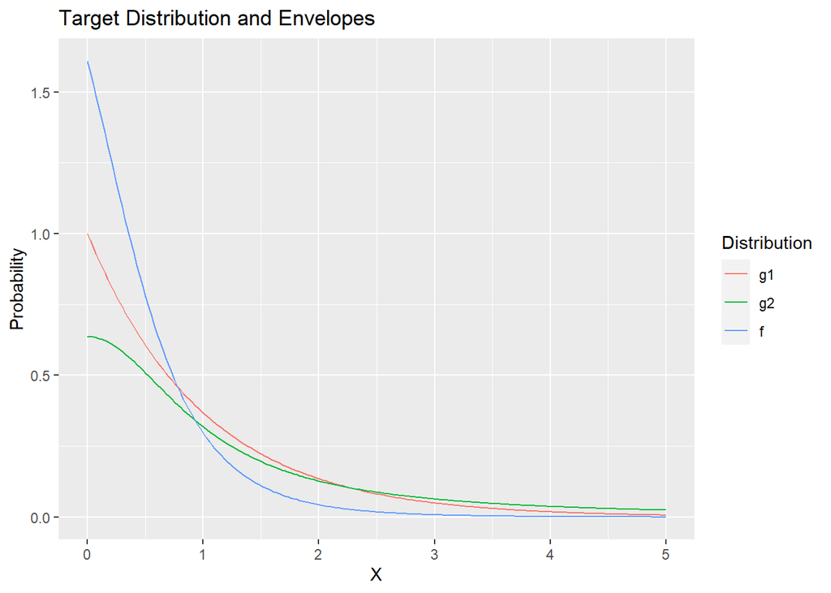

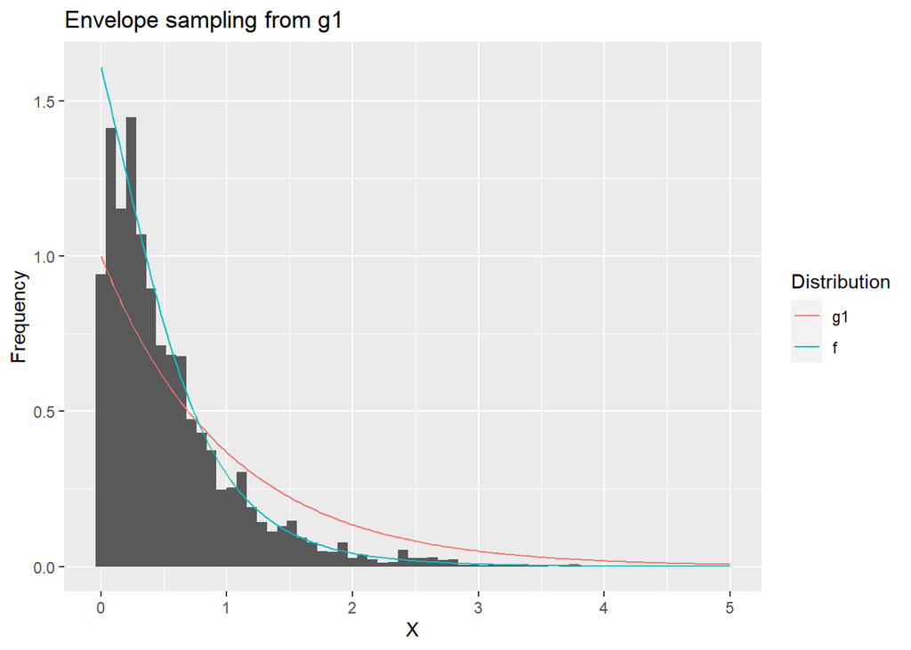

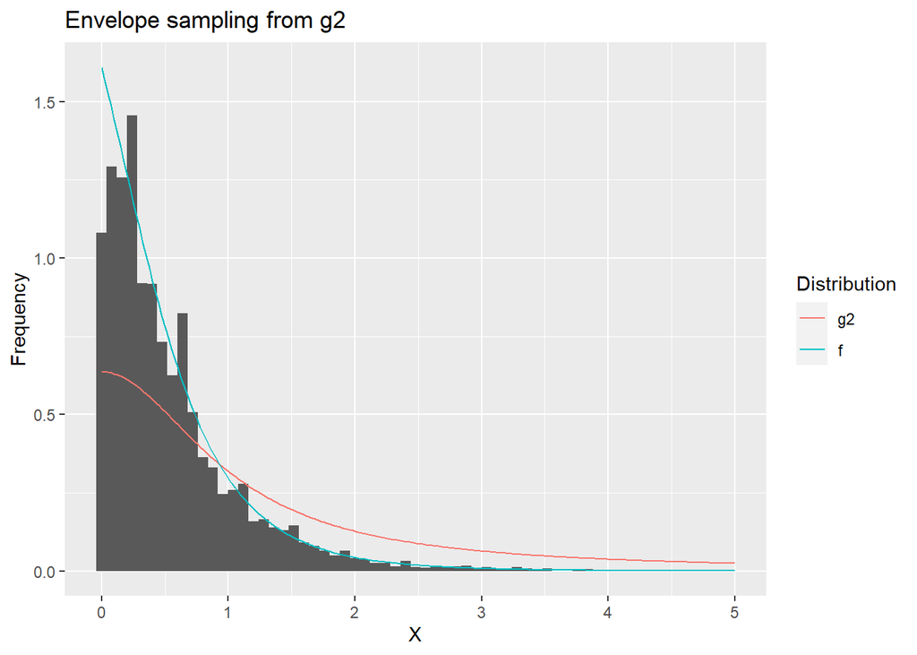